# Appendix C: IRT Modelling with Cleaned Data

Tan, L. Y.

2026-08-24

## 1. Reshaping Dataframe

The following are the codes for further preprocessing prior to applying bigIRT:

```r
# Load the file
f <- "df_irt_itemv.csv"
hdr <- names(fread(f, nrows = 0))          # person IDs are the header


# Wide format
wide <- fread(f, header = TRUE,
              colClasses = c("character", rep("integer", length(hdr) - 1L)),
              na.strings = c("NA", "", ".", "NULL"))
setnames(wide, 1, "Item")

setDT(wide)
setnames(wide, c("Item", as.character(unlist(wide[1, -1]))))
wide <- wide[-1]
for (j in names(wide)[-1]) set(wide, j = j, value = as.integer(wide[[j]]))


# Apply melt in batches
id_col      <- "Item"
person_cols <- setdiff(names(wide), id_col)

chunks <- split(person_cols, ceiling(seq_along(person_cols) / 2000L))
out    <- vector("list", length(chunks))

for (k in seq_along(chunks)) {
  sub <- wide[, c(id_col, chunks[[k]]), with = FALSE]
  out[[k]] <- melt(sub, id.vars = id_col,
                   variable.name = "id", value.name = "score",
                   na.rm = TRUE, variable.factor = FALSE)
  cat(k, "/", length(chunks), "- kept", nrow(out[[k]]), "\n")
}
```

```
## 1 / 22 - kept 120092
## 2 / 22 - kept 98435
## 3 / 22 - kept 74948
## 4 / 22 - kept 70916
## 5 / 22 - kept 116976
## 6 / 22 - kept 123868
## 7 / 22 - kept 92289
## 8 / 22 - kept 102566
## 9 / 22 - kept 96758
## 10 / 22 - kept 127082
## 11 / 22 - kept 126060
## 12 / 22 - kept 103640
## 13 / 22 - kept 111493
## 14 / 22 - kept 86864
## 15 / 22 - kept 100370
## 16 / 22 - kept 97575
## 17 / 22 - kept 121113
## 18 / 22 - kept 94136
## 19 / 22 - kept 77890
## 20 / 22 - kept 69097
## 21 / 22 - kept 111841
## 22 / 22 - kept 29289
```

```r
# Convert into long format for bigIRT
long <- rbindlist(out); rm(out, wide); gc()
```

```
##           used (Mb) gc trigger  (Mb)  max used   (Mb)
## Ncells 1683260 89.9    3277135 175.1   3277135  175.1
## Vcells 9006498 68.8  125778591 959.7 157223040 1199.6
```

```r
long[, Scale := "1"]                        # Required for fitIRT()
long[, score := as.integer(score)]
setcolorder(long, c("id", "Item", "Scale", "score"))
stopifnot(!anyNA(long), all(long$score %in% c(0L, 1L)))

# Check stats before fitting
Np <- uniqueN(long$id); Ni <- uniqueN(long$Item)
#nrow(long) / (Np * Ni)                      # observed density = 0.01696261
#mean(long$score)                            # overall p-value = 0.7075237
```

### 2. Summary Statistics

#### 2.1 Per-Person Summary

Below are the summary statistics on the number of items responded per individual:

```r
# Check distribution again for person & item
per_person <- long[, .N, by = id][order(N)]

summary(per_person$N) # summary stats
```

```
##    Min. 1st Qu.  Median    Mean 3rd Qu.    Max.
##    1.00   30.00   50.00   50.74   60.00  482.00
```

```r
sd(per_person$N)      # SD
```

```
## [1] 28.10221
```

And here is the per person boxplot:

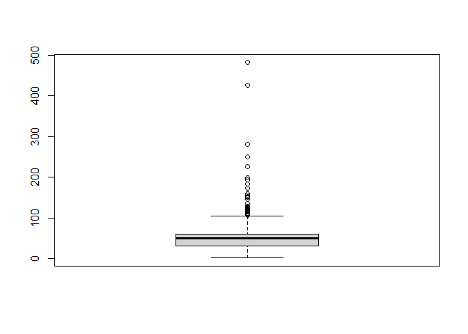

```r
# Plot boxplots
boxplot(per_person$N)
```

#### 2.2 Per-Item Summary

Likewise, the summary statistics per item:

```r
# Check distribution again for item
per_item   <- long[, .N, by = Item][order(N)]

summary(per_item$N)   #summary stats
```

```
##    Min. 1st Qu.  Median    Mean 3rd Qu.    Max.
##     2.0   388.0   667.0   714.9   973.0  2406.0
```

```r
sd(per_item$N)        #SD
```

```
## [1] 389.8101
```

Per-item boxplot:

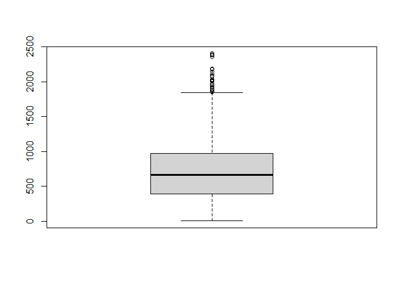

```r
# Plot boxplots
boxplot(per_item$N)
```

### 3. Final Cleaning Round

#### 3.1 Fragmentation checks

One last step checking for fragmentation of observations before IRT modelling (i.e., due to a lack of linking items, causing responses to form isolated groups):

```r
# Check sparsity by analyzing the data as a graph
g <- graph_from_data_frame(
       long[, .(from = paste0("P_", id), to = paste0("I_", Item))],
       directed = FALSE)
cmp <- components(g)
cmp$no                    # want 1
```

```
## [1] 2
```

```r
sort(cmp$csize, decreasing = TRUE)[1:10]
```

```
##  [1] 45208   246    NA    NA    NA    NA    NA    NA    NA    NA
```

```r
# Keep only the largest component if fragmented
gc_v  <- names(cmp$membership)[cmp$membership == which.max(cmp$csize)]
keepP <- sub("^P_", "", grep("^P_", gc_v, value = TRUE))  # N = 45208 is the largest component
keepI <- sub("^I_", "", grep("^I_", gc_v, value = TRUE))
long  <- long[id %in% keepP & Item %in% keepI]
rm(g, cmp); gc()
```

```
##            used (Mb) gc trigger  (Mb)  max used   (Mb)
## Ncells  1755507 93.8    3277135 175.1   3277135  175.1
## Vcells 11500160 87.8  100622873 767.7 157223040 1199.6
```

The data formed 2 fragments, and the largesr component had N = 45208 responses. 246 responses had to be dropped due to fragmentation.

### 3.2 Removing perfect scores

Final round of cleaning to remove items / persons with perfect scores:

```r
# Check for perfect scores for removal
d0 <- copy(long)
d1 <- dropPerfectScores(d0, scoreref. = "score", itemref. = "Item", idref. = "id")
uniqueN(long$id)   - uniqueN(d1$id)      # persons lost
```

```
## [1] 1615
```

```r
uniqueN(long$Item) - uniqueN(d1$Item)    # items lost
```

```
## [1] 7
```

Another 1615 responses and 7 items dropped from the dataframe. Next, to fit 1-IRT using bigIRT on the final cleaned dataframe.

## 4. Fitting 1-IRT using bigIRT

Model fitting using bigIRT:

```r
# Fit the model with a subset of data
set.seed(1)

fit <- fitIRT(
  long,
  score = 'score', id = 'id', item = 'Item', scale = 'Scale',
  pl    = 1,                 # Rasch: A=1, C=0, D=1 fixed
  cores = 6,                 # parallelised by splitting on id
  dropPerfectScores = TRUE,
  ebayes = TRUE,             # priors adapted from a first-pass estimate
  priors = TRUE,
  normalise = TRUE,
  iter = 2000
)
```

```
## Free estimation step...
```

```
## Empirical Bayes step...
```

```r
# Extract results
itemPars   <- as.data.table(fit$itemPars)    # Item, A, B, C, D  (A=1, C=0, D=1 at pl=1)
personPars <- as.data.table(fit$personPars)  # Not important but just in case
                                             # Only had person estimates for N = 40587
```

Check which items were dropped:

```r
# List items dropped
setdiff(unique(long$Item), itemPars$Item)
```

```
## [1] "X2652" "X4546" "X5776" "X2598" "X6084" "X84"   "X87"
```

Extract and save item parameters:

```r
# Normalize the parameters
np <- normaliseIRT(B = itemPars$B, Ability = personPars[[2]],
                   A = itemPars$A, normbase = 'Ability', robust = FALSE)


# Extract estimates
itemPars <- as.data.table(fit$itemPars)
setnames(itemPars, 1, "Item")
itemPars[, .(nItems = .N, A = uniqueN(A), C = uniqueN(C), D = uniqueN(D))]
```

```
##    nItems     A     C     D
##     <int> <int> <int> <int>
## 1:   2999     1     1     1
```

```r
personPars <- as.data.table(fit$personPars)   # Need this for Wright Map later
setnames(personPars, 1, "id")
theta_col <- names(personPars)[2]
```

Check correlation between item estimates and item scores:

```r
# Check correlation between item estimates and item scores:
pvals <- long[, .(p_correct = mean(score), n_obs = .N), by = Item]
chk   <- merge(itemPars, pvals, by = "Item")

cor(chk$B, chk$p_correct, method = "spearman")        # Should be r = -.95 or better; r = -0.9543101
```

```
## [1] -0.9543111
```

Correlation at r = -0.95 or better is a good sign that bigIRT worked properly with the observations.

### 4.1 Summary of Resulting Item Estimates

Overall statistics of item estimates; bigIRT does not have the same functionality as WinSteps but it gives a rough idea on item separation:

```r
# View summary of item estimates
summary(itemPars$B)
```

```
##    Min. 1st Qu.  Median    Mean 3rd Qu.    Max.
## -3.6750 -1.6552 -0.8711 -0.9202 -0.1278  1.4301
```

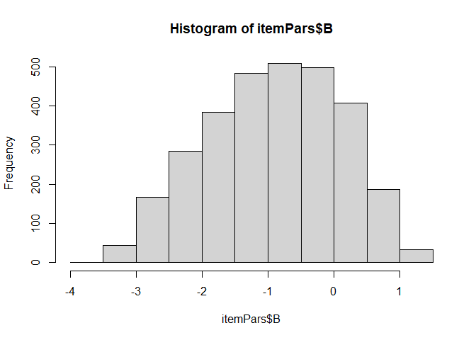

```r
hist(itemPars$B)
```

Plot Wright map to see how well-targeted are the person and item measures:

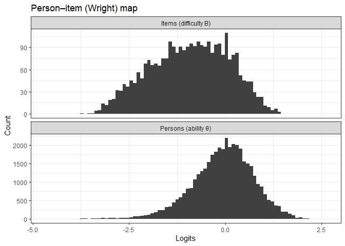

```r
# Plot Wright map
wm <- rbind(
  data.table(logit = personPars[[theta_col]], type = "Persons (ability θ)"),
  data.table(logit = itemPars$B,              type = "Items (difficulty B)")
)
ggplot(wm, aes(logit)) +
  geom_histogram(bins = 80, fill = "grey25") +
  facet_wrap(~type, ncol = 1, scales = "free_y") +
  labs(x = "Logits", y = "Count", title = "Person–item (Wright) map") +
  theme_bw()
```

Results suggest that the items are well-targeted although there might be a floor effect.

### 4.2 Item Fit Statistics

The following are the codes for computing item fit statistics:

```r
# Construct data table
d <- data.table(
  item_i = as.integer(fit$dat$item),
  id_i   = as.integer(fit$dat$id),
  score  = as.integer(fit$dat$score)
)
d[, `:=`(Item  = itemPars$Item[item_i],
         id    = personPars$id[id_i],
         theta = personPars[[theta_col]][id_i],
         A = itemPars$A[item_i], B = itemPars$B[item_i],
         C = itemPars$C[item_i], D = itemPars$D[item_i])]

d[, P := C + (D - C) / (1 + exp(-A * (theta - B)))]   # 4PL; reduces to 1/(1+exp(-(θ-B))) at pl=1


d[, `:=`(W = P * (1 - P), resid = score - P)]
d[, Ck := W * ((1 - P)^3 + P^3)]        # E[(x - P)^4] for a Bernoulli

itemfit <- d[, .(
  N      = .N,
  pObs   = mean(score),
  pExp   = mean(P),
  SE_B   = 1 / sqrt(sum(W)),                    # Fisher information for B, θ treated as known
  outfit = mean(resid^2 / W),                   # unweighted mean square
  infit  = sum(resid^2) / sum(W),               # information-weighted mean square
  q_out  = sqrt(sum(Ck / W^2 - 1)) / .N,
  q_in   = sqrt(sum(Ck - W^2)) / sum(W)
), by = .(item_i, Item)]

# Wilson–Hilferty standardisation (Wright & Masters)
itemfit[, `:=`(outfit_z = (outfit^(1/3) - 1) * (3/q_out) + q_out/3,
               infit_z  = (infit^(1/3)  - 1) * (3/q_in)  + q_in/3)]

itemfit <- merge(itemfit, itemPars, by = "Item")
setorder(itemfit, B)
itemfit[]
```

```
##         Item item_i     N      pObs      pExp       SE_B    outfit     infit
##       <char>  <int> <int>     <num>     <num>      <num>     <num>     <num>
##    1:   X518   2079   659 0.9924127 0.9918121 0.48684946 0.3118931 0.7833070
##    2:   X506   2042   367 0.9809264 0.9798761 0.39883485 0.7132550 0.9343338
##    3:  X1164    168   360 0.9861111 0.9851347 0.44772028 0.7741330 0.9743458
##    4:   X458   1898  1374 0.9774381 0.9771474 0.20133909 0.7896788 0.8808951
##    5:   X902   2894   706 0.9872521 0.9867942 0.34678936 0.7021597 0.8339924
##   ---
## 2995: X14041    384   916 0.1506550 0.1510150 0.09934009 0.7612779 0.9462819
## 2996: X16715    608   693 0.1789322 0.1793894 0.10837771 0.7784571 0.8854879
## 2997:  X2062    907  1388 0.1383285 0.1385668 0.08356786 1.3451611 1.0228877
## 2998:  X8382   2813   994 0.1267606 0.1270994 0.10296686 0.6971547 0.9009319
## 2999:  X2209   1008   977 0.1371546 0.1375069 0.09989855 1.0782676 0.9702169
##           q_out       q_in    outfit_z     infit_z        A         B     C
##           <num>      <num>       <num>       <num>    <num>     <num> <num>
```

[output cut: 24 more lines]

Dot-and-Whisker plot for item estimates:

```
## `height` was translated to `width`.
```

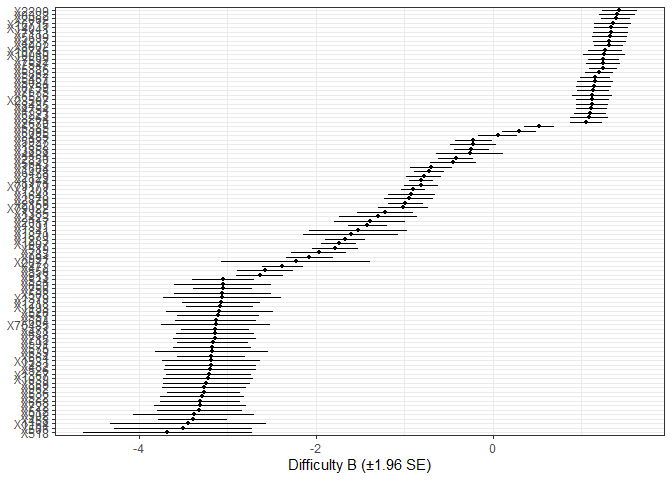

```r
# Dot and whisker plot with CI for estimates
cp <- rbind(head(itemfit, 35), itemfit[sample(.N, 35)], tail(itemfit, 25))
cp <- unique(cp, by = "Item")                      # drop the collided rows
cp[, Item := factor(Item, levels = Item[order(B)])]

ggplot(cp, aes(B, Item)) +
      geom_errorbarh(aes(xmin = B - 1.96*SE_B, xmax = B + 1.96*SE_B), height = 0) +
      geom_point(size = 1) +
      labs(x = "Difficulty B (±1.96 SE)", y = NULL) + theme_bw()
```

Check item separation statistics:

```r
# Computation for item separation
itemfit[, `:=`(Wbar = 1/(SE_B^2 * N),
               d_floor = log10(SE_B) - log10(2/sqrt(N)))]

MSE  <- mean(itemfit$SE_B^2)
SDo  <- sd(itemfit$B)
G    <- sqrt(max(SDo^2 - MSE, 0)/MSE)   # item separation index
c(separation = G, reliability = G^2/(1 + G^2))
```

```
##  separation reliability
##   6.2489462   0.9750308
```

Results show separation at 6.25 levels with item reliability of 0.975.